# Statistical Rethinking | Chapter 3 Exercise

Dilsad

5/6/2021

## Easy

The Easy problems use the samples from the posterior distribution for the globe tossing example. This code will give you a specific set of samples, so that you can check your answers exactly.

```r
p_grid <- seq( from=0 , to=1 , length.out=1000 )
prior <- rep( 1 , 1000 )
likelihood <- dbinom( 6 , size=9 , prob=p_grid )
posterior <- likelihood * prior
posterior <- posterior / sum(posterior)
set.seed(100)
samples <- sample( p_grid , prob=posterior , size=1e4 , replace=TRUE )

head(samples)
```

```
## [1] 0.7137137 0.3573574 0.5985986 0.7177177 0.6296296 0.4694695
```

3E1. How much posterior probability lies below p = 0.2?

```r
sum(posterior[ p_grid < 0.2 ])
```

```
## [1] 0.0008560951
```

3E2. How much posterior probability lies above p = 0.8?

```r
sum(posterior[ p_grid > 0.8 ])
```

```
## [1] 0.1203449
```

3E3. How much posterior probability lies between p = 0.2 and p = 0.8?

```r
sum(posterior[ 0.2 < p_grid & p_grid < 0.8 ])
```

```
## [1] 0.878799
```

3E4. 20% of the posterior probability lies below which value of p?

```r
quantile(samples, 0.2)
```

```
##       20%
## 0.5185185
```

3E5. 20% of the posterior probability lies above which value of p?

```r
quantile(samples, 0.8)
```

```
##       80%
## 0.7557558
```

3E6. Which values of p contain the narrowest interval equal to 66% of the posterior probability?

```r
library(rethinking)
# HPDI function calculates "highest posterior density interval"
HPDI( samples , prob=0.66 )
```

```
##     |0.66     0.66|
## 0.5085085 0.7737738
```

3E7. Which values of p contain 66% of the posterior probability, assuming equal posterior probability both below and above the interval?

```r
library(rethinking)
# PI function calculates "percentile intervals"
PI( samples , prob=0.66 )
```

```
##       17%       83%
## 0.5025025 0.7697698
```

## Medium

3M1. Suppose the globe tossing data had turned out to be 8 water in 15 tosses. Construct the posterior distribution, using grid approximation.  
Use the same flat prior as before.

```r
p_grid <- seq( from=0 , to=1 , length.out=1000 )
prior <- rep( 1 , 1000 )
likelihood <- dbinom( 8 , size=15 , prob=p_grid )
posterior <- likelihood * prior
posterior <- posterior / sum(posterior)
str(posterior)
```

```
##  num [1:1000] 0.00 1.03e-22 2.62e-20 6.67e-19 6.62e-18 ...
```

3M2. Draw 10,000 samples from the grid approximation from above. Then use the samples to calculate the 90% HPDI for p.

```r
set.seed(100)
samples <- sample( p_grid , prob=posterior , size=1e4 , replace=TRUE )
head(samples)
```

```
## [1] 0.4694695 0.3573574 0.4794795 0.4704705 0.5025025 0.3983984
```

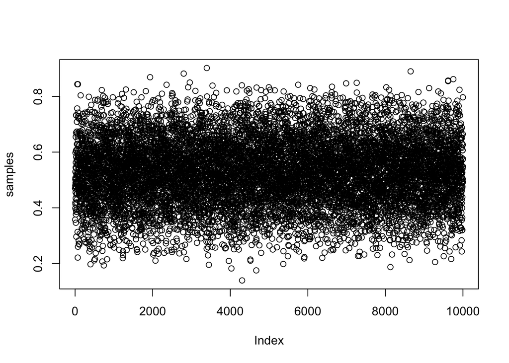

```r
plot(samples)
```

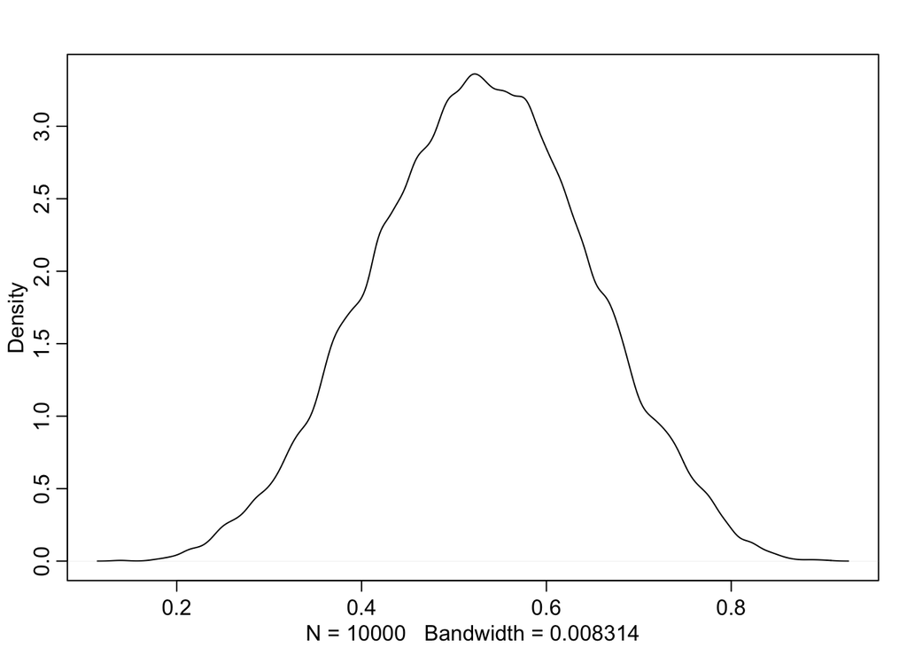

```r
dens(samples)
```

```r
HPDI(samples, prob=0.9)
```

```
##      |0.9      0.9|
## 0.3343343 0.7217217
```

3M3. Construct a posterior predictive check for this model and data. This means simulate the distribution of samples, averaging over the posterior uncertainty in p. What is the probability of observing 8 water in 15 tosses?

```r
dummy <- rbinom(1e4 , size=15 , prob=samples)
table(dummy)/1e4
```

```
## dummy
##      0      1      2      3      4      5      6      7      8      9     10
## 0.0004 0.0037 0.0125 0.0265 0.0508 0.0861 0.1155 0.1338 0.1499 0.1397 0.1158
##     11     12     13     14     15
## 0.0806 0.0475 0.0249 0.0105 0.0018
```

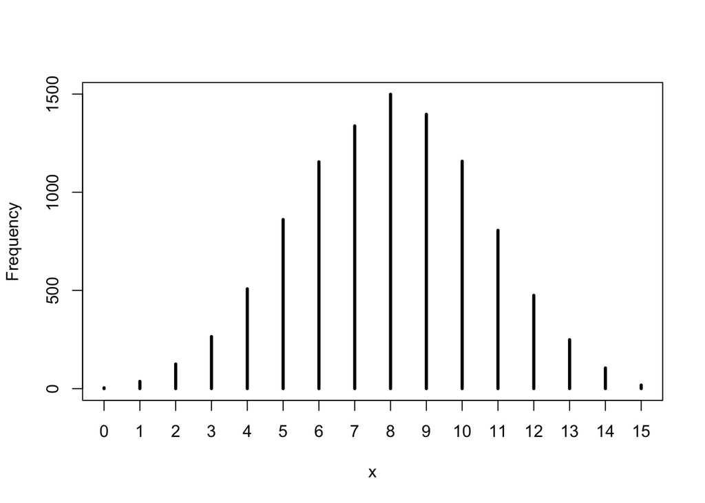

```r
library(rethinking)
simplehist(dummy)
```

3M4. Using the posterior distribution constructed from the new (8/15) data, now calculate the probability of observing 6 water in 9 tosses.

```r
dummy <- rbinom(1e4 , size=9 , prob=samples)
table(dummy)/1e4
```

```
## dummy
##      0      1      2      3      4      5      6      7      8      9
## 0.0042 0.0276 0.0753 0.1363 0.1901 0.2074 0.1842 0.1107 0.0520 0.0122
```

3M5. Start over at 3M1, but now use a prior that is zero below p = 0.5 and a constant above p = 0.5. This corresponds to prior information that a majority of the Earth’s surface is water. Repeat each problem above and compare the inferences. What difference does the better prior make? If it helps, compare inferences (using both priors) to the true value p = 0.7.

```r
p_grid <- seq( from=0 , to=1 , length.out=1000 )
prior <- ifelse( p_grid < 0.5 , 0 , 1 )
likelihood <- dbinom( 8 , size=15 , prob=p_grid )
posterior <- likelihood * prior
posterior <- posterior / sum(posterior)
str(posterior)
```

```
##  num [1:1000] 0 0 0 0 0 0 0 0 0 0 ...
```

```r
samples <- sample( p_grid , prob=posterior , size=1e4 , replace=TRUE )
head(samples)
```

```
## [1] 0.5265265 0.5585586 0.5165165 0.5085085 0.6456456 0.6876877
```

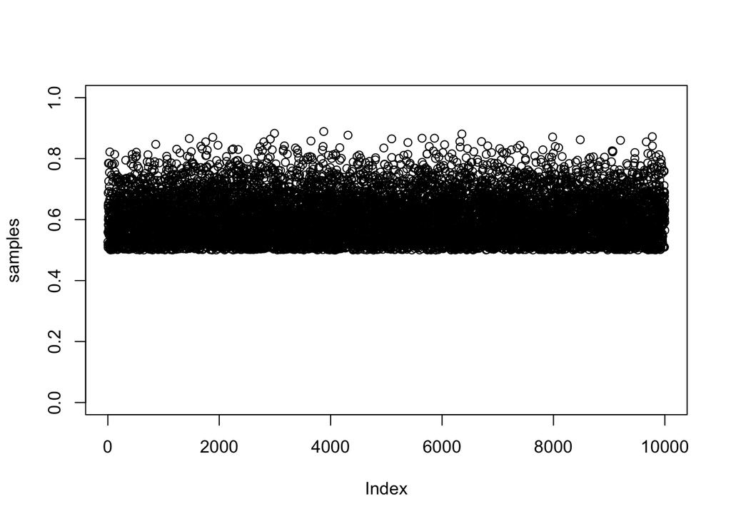

```r
plot(samples, ylim = c(0,1))
```

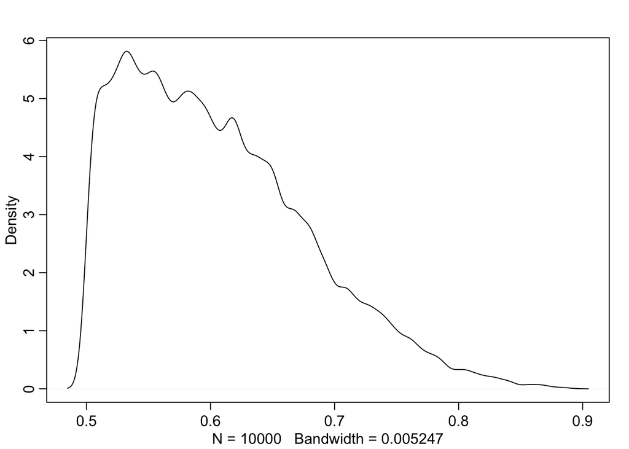

```r
dens(samples)
```

```r
HPDI(samples, prob=0.9)
```

```
##      |0.9      0.9|
## 0.5005005 0.7107107
```

```r
dummy <- rbinom(1e4 , size=15 , prob=samples)
table(dummy)/1e4
```

```
## dummy
##      1      2      3      4      5      6      7      8      9     10     11
## 0.0002 0.0006 0.0026 0.0114 0.0329 0.0668 0.1183 0.1521 0.1772 0.1658 0.1317
##     12     13     14     15
## 0.0830 0.0419 0.0128 0.0027
```

3M6. Suppose you want to estimate the Earth’s proportion of water very precisely. Specifically, you want the 99% percentile interval of the posterior distribution of p to be only 0.05 wide. This means the distance between the upper and lower bound of the interval should be 0.05. How many times will you have to toss the globe to do this?

```r
p_grid <- seq( from=0 , to=1 , length.out=1000 )
prior <- rep( 1 , 1000 )
likelihood <- dbinom( 8000 , size=12000 , prob=p_grid )
posterior <- likelihood * prior
posterior <- posterior / sum(posterior)
str(posterior)
```

```
##  num [1:1000] 0 0 0 0 0 0 0 0 0 0 ...
```

```r
samples <- sample( p_grid , prob=posterior , size=1e4 , replace=TRUE )
head(samples)
```

```
## [1] 0.6616617 0.6696697 0.6666667 0.6656657 0.6666667 0.6636637
```

```r
HPDI(samples, prob=0.99)
```

```
##     |0.99     0.99|
## 0.6546547 0.6766767
```

```r
p_grid <- seq( from=0 , to=1 , length.out=1000 )
prior <- rep( 1 , 1000 )
likelihood <- dbinom( 2000 , size=12000 , prob=p_grid )
posterior <- likelihood * prior
posterior <- posterior / sum(posterior)
str(posterior)
```

```
##  num [1:1000] 0 0 0 0 0 0 0 0 0 0 ...
```

```r
samples <- sample( p_grid , prob=posterior , size=1e4 , replace=TRUE )
head(samples)
```

```
## [1] 0.1681682 0.1671672 0.1691692 0.1681682 0.1711712 0.1661662
```

```r
HPDI(samples, prob=0.99)
```

```
##     |0.99     0.99|
## 0.1581582 0.1751752
```

```r
p_grid <- seq( from=0 , to=1 , length.out=1000 )
prior <- rep( 1 , 1000 )
likelihood <- dbinom( 1 , size=12000 , prob=p_grid )
posterior <- likelihood * prior
posterior <- posterior / sum(posterior)
str(posterior)
```

```
##  num [1:1000] 0.00 1.00 1.19e-05 1.06e-10 8.20e-16 ...
```

```r
samples <- sample( p_grid , prob=posterior , size=1e4 , replace=TRUE )
head(samples)
```

```
## [1] 0.001001001 0.001001001 0.001001001 0.001001001 0.001001001 0.001001001
```

```r
HPDI(samples, prob=0.99)
```

```
##       |0.99       0.99|
## 0.001001001 0.001001001
```

```r
# if we compare the very low values (1 here) andbery high values (8000 in the 1st one) you will see more difference between them in terms of precision. Because the extremes are less uncertain than the middle values.
```

## Hard

The Hard problems here all use the data below.  
These data indicate the gender (male=1, female=0) of officially reported first and second born children in 100 two-child families.

```r
birth1 <- c(1,0,0,0,1,1,0,1,0,1,0,0,1,1,0,1,1,0,0,0,1,0,0,0,1,0,
0,0,0,1,1,1,0,1,0,1,1,1,0,1,0,1,1,0,1,0,0,1,1,0,1,0,0,0,0,0,0,0,
1,1,0,1,0,0,1,0,0,0,1,0,0,1,1,1,1,0,1,0,1,1,1,1,1,0,0,1,0,1,1,0,
1,0,1,1,1,0,1,1,1,1)

birth2 <- c(0,1,0,1,0,1,1,1,0,0,1,1,1,1,1,0,0,1,1,1,0,0,1,1,1,0,
1,1,1,0,1,1,1,0,1,0,0,1,1,1,1,0,0,1,0,1,1,1,1,1,1,1,1,1,1,1,1,1,
1,1,1,0,1,1,0,1,1,0,1,1,1,0,0,0,0,0,0,1,0,0,0,1,1,0,0,1,0,0,1,1,
0,0,0,1,1,1,0,0,0,0)
```

So for example, the first family in the data reported a boy (1) and then a girl (0). The second family reported a girl (0) and then a boy (1). The third family reported two girls. You can load these two vectors into R’s memory by typing:

```r
library(rethinking)
data(homeworkch3)
```

Use these vectors as data. So for example to compute the total number of boys born across all of these births, you could use:

```r
sum(birth1) + sum(birth2)
```

```
## [1] 111
```

3H1. Using grid approximation, compute the posterior distribution for the probability of a birth being a boy. Assume a uniform prior probability. Which parameter value maximizes the posterior probability?

```r
p_grid <- seq( from=0 , to=1 , length.out=1000 )
prior <- rep( 1 , 1000 )
boys <- sum(birth1) + sum(birth2)
likelihood <- dbinom( boys , size=200 , prob=p_grid )
posterior <- likelihood * prior
posterior <- posterior / sum(posterior)
str(posterior)
```

```
##  num [1:1000] 0.00 5.57e-276 1.32e-242 4.26e-223 2.87e-209 ...
```

```r
p_grid[which.max(posterior)]
```

```
## [1] 0.5545546
```

3H2. Using the sample function, draw 10,000 random parameter values from the posterior distribution you calculated above. Use these samples to estimate the 50%, 89%, and 97% highest posterior density intervals.

```r
samples <- sample( p_grid , prob=posterior , size=1e4 , replace=TRUE )
head(samples)
```

```
## [1] 0.5265265 0.5415415 0.5265265 0.5125125 0.6026026 0.5375375
```

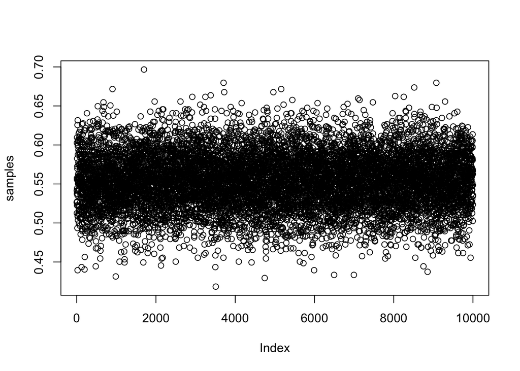

```r
plot(samples)
```

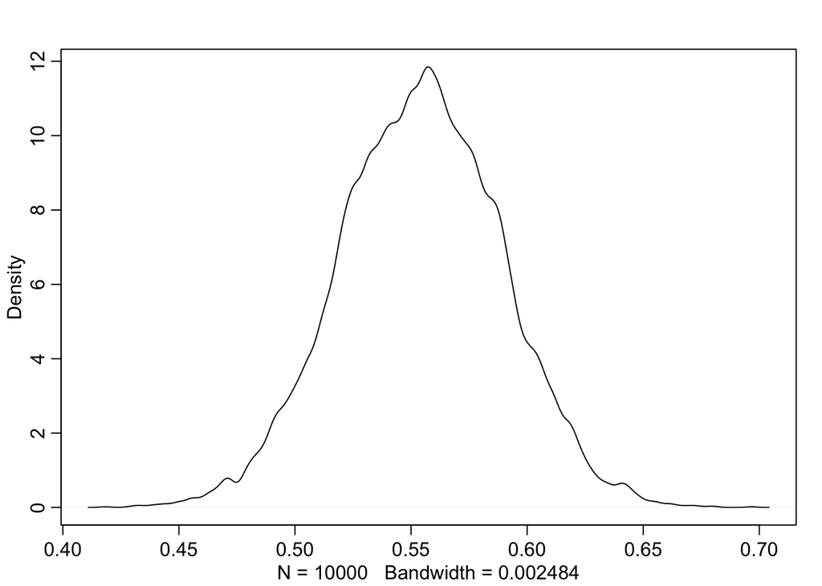

```r
dens(samples)
```

```r
HPDI(samples, prob=0.50)
```

```
##      |0.5      0.5|
## 0.5255255 0.5725726
```

```r
HPDI(samples, prob=0.89)
```

```
##     |0.89     0.89|
## 0.4964965 0.6076076
```

```r
HPDI(samples, prob=0.97)
```

```
##     |0.97     0.97|
## 0.4774775 0.6276276
```